# Applictaions of Fourier Transform

## Kianoush Arshi 810198438

- Convolution in Frequency Domain
- Narrow band Temporal Filtering
- Image Filtering 2D
- Low Pass Filtering
  - Part A
  - Part B
- High Pass Filtering
  - Part A
  - Part B

# Convolution in Frequency Domain

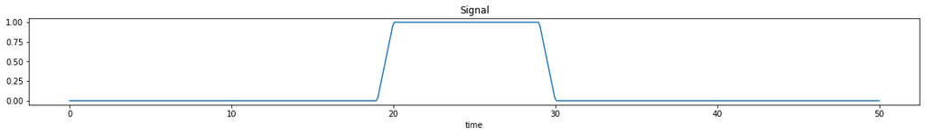

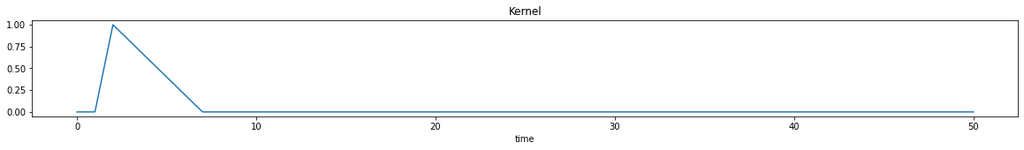

```python
plot_transform(time_range, _signal, title="Signal", xlabel="time", ylabel="")

plot_transform(time_range, _kernel, title="Kernel", xlabel="time", ylabel="")
```

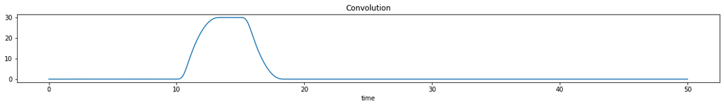

```python
time_range = np.linspace(0, 50, 999)

_convolution = np.convolve(_signal, _kernel, mode="full")
plot_transform(time_range, _convolution, title="Convolution", xlabel="time", ylabel="")
```

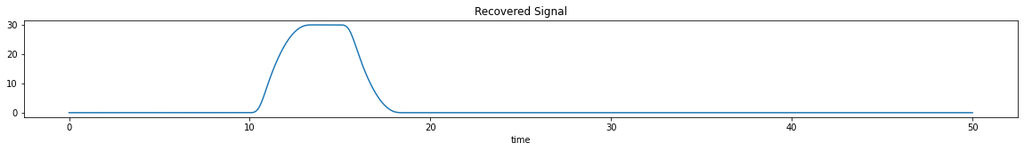

```python
fft_signal = fft(_signal)
fft_kernel = fft(_kernel)
fft_convolution = fft_signal*fft_kernel
ifft_convolution = np.real(ifft(fft_convolution))

plot_transform(time_range, ifft_convolution, title="Recovered Signal", xlabel="time", ylabel="")
```

# Narrow band Temporal Filtering

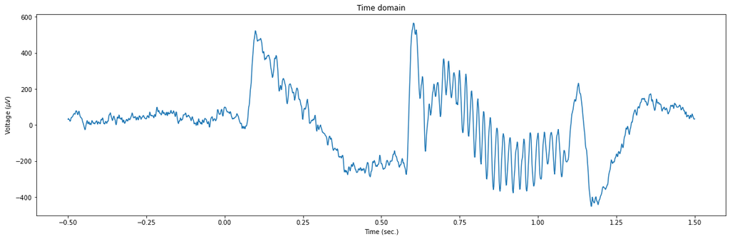

```python
plot_transform(timevec, braindata, title="Time domain", xlabel="Time (sec.)", ylabel="Voltage ($\\mu V$)", _figsize=(20, 6))
```

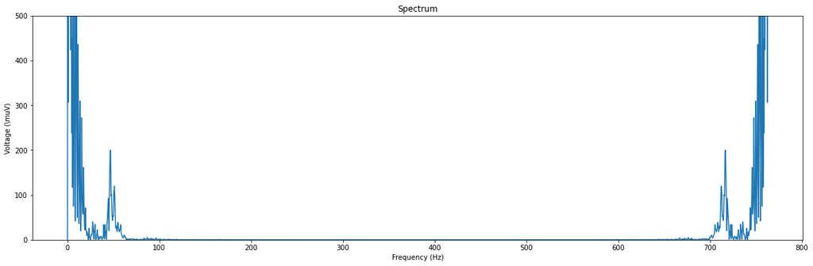

```python
sample_rate = matdata['srate'][0]
braindata_fourier = fft(braindata)/len(timevec)
power_spectrum = 2*np.abs(braindata_fourier)**2
freq_range = np.linspace(0, sample_rate, len(timevec))

plot_transform(freq_range,power_spectrum[0:len(freq_range)], title="Spectrum", xlabel="Frequency (Hz)", ylabel="Voltage (\muV)", _figsize=(20, 6), _ylim=True)
```

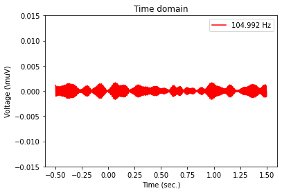

```python
filtered_1 = 2*np.real(ifft(np.multiply(braindata_fourier,gaussian_filter_1) ))
filtered_2 = 2*np.real(ifft(np.multiply(braindata_fourier,gaussian_filter_2) ))

plt.plot(timevec,filtered_1, c='r', label='%g Hz' %freq_1)
plt.ylim([-0.015, 0.015])
plt.xlabel('Time (sec.)')
plt.ylabel('Voltage (\muV)')
plt.title('Time domain')

plt.legend()
plt.show()
```

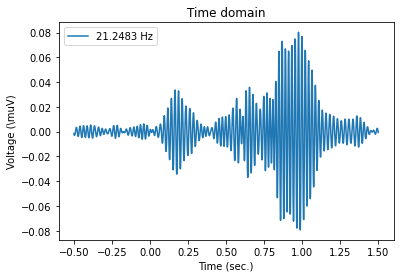

```python
plt.plot(timevec,filtered_2, label='%g Hz' %freq_2)

plt.xlabel('Time (sec.)')
plt.ylabel('Voltage (\muV)')
plt.title('Time domain')

plt.legend()
plt.show()
```

Based on the shift filters applied to our frequency, by increasing the shift, the voltage range will decrease and the signal will become less unpredictable and more linear. The peaks in our plot will be closer to 0 with greater shifting

# Image Filtering 2D

```python
img = np.asarray(Image.open("Lenna.png"), dtype=int)
```

# Part 1A

```
New matrix shape: (512, 512)
```

[figure not shown]

```python
bw_img = img.mean(axis=2, keepdims=False)
print("New matrix shape:", bw_img.shape)
plt.imshow(bw_img, cmap='gray')
```

# Part 1B

**fftshift(X)** rearranges the outputs of fft, fft2, and fftn by moving the zero-frequency component to the center of the array.  
It is useful for visualizing a Fourier transform with the zero-frequency component in the middle of the spectrum.

For vectors, fftshift(X) swaps the left and right halves of X. For matrices, fftshift(X) swaps the first quadrant with the third and the second quadrant with the fourth.

**fft2(X)** returns the two-dimensional Fourier transform of a matrix using a fast Fourier transform algorithm, which is equivalent to computing fft(fft(X).').'. If X is a multidimensional array, then fft2 takes the 2-D transform of each dimension higher than 2. The output Y is the same size as X.

[figure not shown]

```python
ffs = ifft2(ifftshift(bw_shifted))
log_spectrum = np.square(np.abs(ffs))

plt.imshow(log_spectrum, cmap = 'gray')
```

Now, let's blur it!

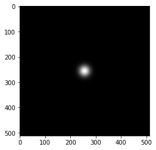

```python
plt.imshow(gaus2d, cmap='gray')
plt.show()
```

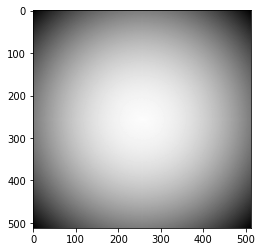

```python
blur = bw_shifted * gaus2d

log_spectrum_blur = np.log(np.abs(blur))

plt.imshow(log_spectrum_blur, cmap='gray')
plt.show()
```

[figure not shown]

```python
ffs = ifft2(ifftshift(blur))
power_spectrum = np.square(np.abs(ffs))

plt.imshow(power_spectrum, cmap = 'gray')
```

# Part 2A

[Reference](https://biomedpharmajournal.org/vol7no2/image-sharpening-by-gaussian-and-butterworth-high-pass-filter/)

[figure not shown]

```python
ffs = ifft2(ifftshift(sharpen))
power_spectrum = np.square(np.abs(ffs))

plt.imshow(power_spectrum, cmap = 'gray')
```

# Part 2B

This filter sharpens the edges of the image.  
The Gaussian low pass filter attenuates frequency components that are further away from the centre (W/2, H/2).  
The Gaussian high pass filter attenuates frequency components that are near to the image center (W/2, H/2).  
In the low pass filter, the edges are softened and as a result the image is blurred. The high pass filter is exactly the opposite, it increases sharpness by decreasing the density of frequency components that are near to the image center and as a result sharpens the edges.